# Problem Set 4

David Bacsik

May 12, 2018

# Problem Set #4

# Due Date: Thursday, May 24th

### Problem 1

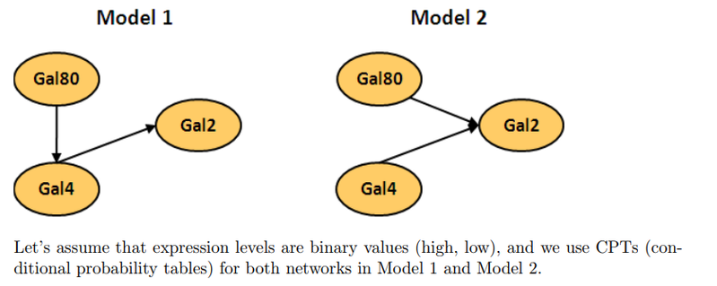

Variables and values: G80: Gal80 Expression, Val(G80) = {G80<sup>0</sup>, G80<sup>1</sup>} G4: Gal4 Expression, Val(G4) = {G4<sup>0</sup>, G4<sup>1</sup>} G2: Gal2 Expression, Val(G2) = {G2<sup>0</sup>, G2<sup>1</sup>}

#### 1a

**Model 1 and Model 2 have different Bayesian network structures, and so they have different sets of parameters (θ). List all parameters and the CPTs in each of Model 1 and Model 2.**

Model 1:  
$\theta_1$ = {G80, G4|G80, G2|G4}

**CPT(Gal80):**

| G80<sup>0</sup> | G80<sup>1</sup> |
| --- | --- |
| P(G80<sup>0</sup>) | P(G80<sup>1</sup>) |

**CPT(Gal4):**

|  | G4<sup>0</sup> | G4<sup>1</sup> |
| --- | --- | --- |
| **G80<sup>0</sup>** | P(G4<sup>0</sup>\|G80<sup>0</sup>) | P(G4<sup>1</sup>\|G80<sup>0</sup>) |
| **G80<sup>1</sup>** | P(G4<sup>0</sup>\|G80<sup>1</sup>) | P(G4<sup>1</sup>\|G80<sup>1</sup>) |

**CPT(Gal2):**

|  | G2<sup>0</sup> | G2<sup>1</sup> |
| --- | --- | --- |
| **G4<sup>0</sup>** | P(G2<sup>0</sup>\|G4<sup>0</sup>) | P(G2<sup>1</sup>\|G4<sup>0</sup>) |
| **G4<sup>1</sup>** | P(G2<sup>0</sup>\|G4<sup>1</sup>) | P(G2<sup>1</sup>\|G4<sup>1</sup>) |

Model 2:  
$\theta_2$ = {G80, G4, G2|G80,G4}

**CPT(Gal80):**

| G80<sup>0</sup> | G80<sup>1</sup> |
| --- | --- |
| P(G80<sup>0</sup>) | P(G80<sup>1</sup>) |

**CPT(Gal4):**

| G4<sup>0</sup> | G4<sup>1</sup> |
| --- | --- |
| P(G4<sup>0</sup>) | P(G4<sup>1</sup>) |

**CPT(Gal2):**

|  | G2<sup>0</sup> | G2<sup>1</sup> |
| --- | --- | --- |
| **G80<sup>0</sup>, G4<sup>0</sup>** | P(G2<sup>0</sup>\|G80<sup>0</sup>, G4<sup>0</sup>) | P(G2<sup>1</sup>\|G80<sup>0</sup>, G4<sup>0</sup>) |
| **G80<sup>0</sup>, G4<sup>1</sup>** | P(G2<sup>0</sup>\|G80<sup>0</sup>, G4<sup>1</sup>) | P(G2<sup>1</sup>\|G80<sup>0</sup>, G4<sup>1</sup>) |
| **G80<sup>1</sup>, G4<sup>0</sup>** | P(G2<sup>0</sup>\|G80<sup>1</sup>, G4<sup>0</sup>) | P(G2<sup>1</sup>\|G80<sup>1</sup>, G4<sup>0</sup>) |
| **G80<sup>1</sup>, G4<sup>1</sup>** | P(G2<sup>0</sup>\|G80<sup>1</sup>, G4<sup>1</sup>) | P(G2<sup>1</sup>\|G80<sup>1</sup>, G4<sup>1</sup>) |

#### 1b

**Say that we are given the gene expression data D measuring binary expression levels of the 3 genes (Gal80, Gal4 and Gal2) across 112 samples. Write down the likelihood function L(D|θ) for Model 1 and Model 2.**

L($\theta$ : D) = P(D|$\theta$)

Model 1:  
$\theta_1$ = {G80, G4|G80, G2|G4}  
$L_1(\theta_1:D) = P(D|\theta_1) = \displaystyle\prod_{i=1}^{112} P(G80 = G80_i) \cdot P(G4 = G4_i | G80_i) \cdot P(G2 = G2_i|G4_i)$

#### 1c

**Write down the maximum likelihood estimation (MLE) solutions in Model 1 and Model 2.**

#### 1d

**Download the binary expression data from https://sites.google.com/a/cs.washington.edu/genome560-spr18/disc-gal80-gal4-gal2.txt?attredirects=0&d=1, and implement the code that computes the log-likelihood function log (L) for Model 1 and Model 2.**

```r
gal_data = read.table('disc-gal80-gal4-gal2.txt', sep='\t', strip.white=TRUE, stringsAsFactors = TRUE)

gal_data = t(gal_data)

colnames(gal_data) = gal_data[1,]
row.names(gal_data) = NULL

gal_data = gal_data[-1,-1]

gal_data = data.frame(gal_data)

gal_data = lapply(gal_data, trimws)

gal_data = lapply(gal_data, as.numeric)

gal_data = data.frame(gal_data)
```

```r
gal80.cpt = prop.table(table(gal_data[c('Gal80')]))

gal4.cpt = prop.table(table(gal_data[c('Gal4')]))

gal4.gal80.cpt = prop.table(table(gal_data[c('Gal80','Gal4')]))

gal2.gal4.cpt = prop.table(table(gal_data[c('Gal4','Gal2')]))

gal2.gal4gal80.cpt = prop.table(table(gal_data[c('Gal80', 'Gal4', 'Gal2')]))

term_prob_1 = function(x){
  g80 = gal_data[x,]$Gal80
  g4 = gal_data[x,]$Gal4
  g2 = gal_data[x,]$Gal2

  p.g80 = as.numeric(gal80.cpt[as.character(g80)])
  p.gal4.gal80 = as.numeric(gal4.gal80.cpt[as.character(g80),as.character(g4)])
  p.gal2.gal4 = as.numeric(gal2.gal4.cpt[as.character(g4),as.character(g2)])

  joint = p.g80 * p.gal4.gal80 * p.gal2.gal4
  return(joint)
}

term_prob_2 = function(x){
  g80 = gal_data[x,]$Gal80
  g4 = gal_data[x,]$Gal4
  g2 = gal_data[x,]$Gal2

  p.g80 = as.numeric(gal80.cpt[as.character(g80)])
  p.gal4 = as.numeric(gal4.cpt[as.character(g4)])
  p.gal2.gal4gal80 = as.numeric(gal2.gal4gal80.cpt[as.character(g80), as.character(g4),as.character(g2)])

  joint = p.g80 * p.gal4* p.gal2.gal4gal80
  return(joint)
}

prod_1 = 1
prod_2 = 1
for (i in  1:nrow(gal_data)){
  j_1 = term_prob_1(i)
  prod_1 = prod_1 * j_1
  j_2 = term_prob_2(i)
  prod_2 = prod_2 * j_2
}

print('log likelihood of model 1:')
```

```
## [1] "log likelihood of model 1:"
```

```r
print(log(prod_1))
```

```
## [1] -373.6576
```

```r
print('log likelihood of model 2:')
```

```
## [1] "log likelihood of model 2:"
```

```r
print(log(prod_2))
```

```
## [1] -370.9857
```

#### 1e

**Select between Model 1 and Model 2 based on the results in part (d).**

The log likelihood of model 2 is greater (less negative). Therefore, I believe model 2 better reflects the data.

### Problem 2

**Here, we will continue the R exercise in Lecture #14. The goal of this exercise is to understand the impact of hyperparameters α and β in a Bernoulli experiment (e.g., Thumbtack example). We will do that by comparing the shape of the distribution between the likelihood P(D|p) and the posterior P(p|D). We assume that our prior belief is that we get the same number of heads and tails (i.e., p = 0.5).**

```r
likelihood <- function(p, nh, nt){
  l = p^nh * (1-p)^nt
  return(l)
}

posterior = function(p, nh, nt, alpha, beta){
  prior = dbeta(p, alpha, beta)
  like = likelihood(p, nh, nt)
  post = (1/prior)*like
  return(post)
}
```

**Consider the following sets of nH, nT , α, and β. Plot the likelihood and posterior functions over varying p in [0, 1] and compare multiple plots. What are the MLE and MAP estimations of p in each case?**

```r
p = seq(0, 1, 0.001)

likepost = function(p, nh, nt, alpha, beta){
  likes = likelihood(p, nh, nt)
  posts = posterior(p, nh, nt, alpha, beta)

  ld = data.frame(p, likes, posts)
  ld

  max_like = p[which.max(likes)]
  print('The maximum likelilhood estimate of p is:')
  print(max_like)

  max_map = p[which.max(posts)]
  print('The maximum posterior estimate of p is:')
  print(max_map)

  plot_like = ggplot(ld, aes(x=p, y=likes)) + geom_point(col='seagreen3') + labs(x='p', y='likelihood')
  plot_post = ggplot(ld, aes(x=p, y=posts)) + geom_point(col='deeppink3') + labs(x='p', y='posterior probability')

  grid.arrange(plot_like, plot_post, ncol=1)
}
```

#### 1a

**Say that nH = 100, nT = 50, α = 5, and β = 5**

```r
nh = 100
nt = 50
alpha = 5
beta = 5

likepost(p, nh, nt, alpha, beta)
```

```
## [1] "The maximum likelilhood estimate of p is:"
## [1] 0.667
## [1] "The maximum posterior estimate of p is:"
## [1] 0.676
```

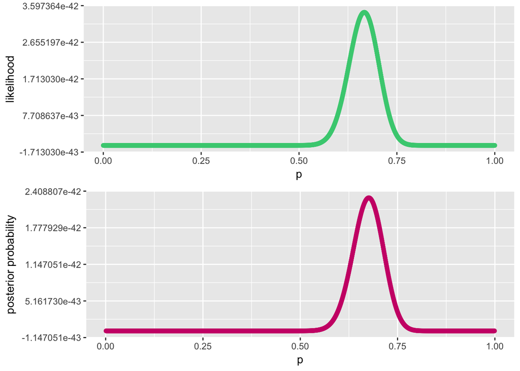

#### 1b

Say that nH = 100, nT = 50, α = 30, and β = 30. (Optional: Describe the difference of the results between (a) and (b) and the reason for the difference.)

In this case, we are adding more pseudocounts, indicating a stronger prior.

```r
nh = 100
nt = 50
alpha = 30
beta = 30

likepost(p, nh, nt, alpha, beta)
```

```
## [1] "The maximum likelilhood estimate of p is:"
## [1] 0.667
## [1] "The maximum posterior estimate of p is:"
## [1] 0.772
```

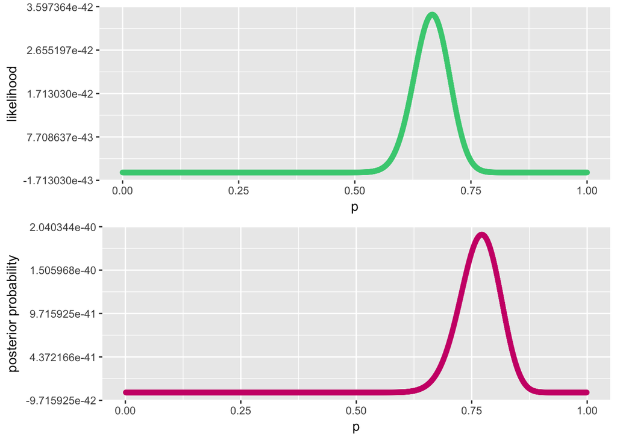

#### 1c

Say that nH = 10, nT = 5, α = 30, and β = 30. (Optional: Describe the difference of the results between (b) and (c) and the reason for the difference.)

```r
nh = 10
nt = 5
alpha = 30
beta = 30

likepost(p, nh, nt, alpha, beta)
```

```
## [1] "The maximum likelilhood estimate of p is:"
## [1] 0.667
## [1] "The maximum posterior estimate of p is:"
## [1] 0.999
```

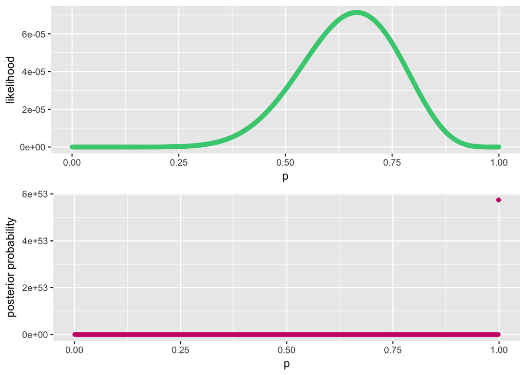